# **Course: Introduction to Data Analytics with Python.**

### **Conditionals and Loops in Python (Advanced)**

**Conditionals** allow you to execute different parts of your code depending on whether a condition is met or not. In Python, this is done with the **`if`**, **`elif`** (else if), and **`else`** keywords.

Imagine you have a number and you want to know if it's positive, negative, or zero. You can use a conditional to check this:

```python
number = 5

if number > 0:
  print("The number is positive.")
elif number < 0:
  print("The number is negative.")
else:
  print("The number is zero.")
```

```
The number is positive.
```

Another example

```python
# Conditional Example
age = 18

if age >= 18:
  print("You are an adult.")
else:
  print("You are a minor.")
```

```
You are an adult.
```

Loops allow you to repeat a piece of code multiple times without having to rewrite it.

A for loop is used when you know how many times you want to repeat something or when you want to iterate through a sequence (such as a list or string). For example, if you have a list of numbers and you want to add them together, you can use a for loop:

```python
numbers = [1, 2, 3, 4, 5]
sum = 0

for num in numbers:
  sum += num

print("The sum is:", sum)
```

```
The sum is: 15
```

Another example

```python
fruits = ["apple", "banana", "cherry", "grape"]

# For loop to iterate over a list
for fruit in fruits:
  print(fruit)
```

```
apple
banana
cherry
grape
```

The `while` loop runs as long as a condition is met. It's useful when you don't know how many times you need to repeat an action, but you know it should continue as long as something is true.

```python
counter = 0

while counter < 5:
  print("Counter:", counter)
  counter += 1
```

```
Counter: 0
Counter: 1
Counter: 2
Counter: 3
Counter: 4
```

### **Recap of section 1**

- **Basic Python Syntax:**
  - Variables and Data Types (assigning values, printing variables).
  - Basic Mathematical Operations (addition, subtraction, multiplication, division).
  - Printing Text.
- **Data Structures:**
  - **Lists:**
    - Defining lists.
    - Accessing elements by index.
    - Modifying elements.
    - Adding elements (`append`, `insert`).
    - Removing elements (`remove`, `pop`).
    - Getting the length (`len`).
    - Slicing (using `start:stop:step`, including negative indices and reversing).
    - Sorting (`sort` with optional `reverse` and `key` arguments).
  - **Other Built-in Structures:**
    - Tuples (ordered, immutable).
    - Sets (unordered, mutable, no duplicates).
    - Dictionaries (unordered, mutable, key-value pairs).
- **Conditionals:**
  - Using `if`, `elif`, and `else` to control code flow based on conditions.
- **Loops:**
  - **`for` loops:** Iterating over sequences (like lists) or for a known number of repetitions.
  - **`while` loops:** Repeating code as long as a condition is True.

**Specific Commands/Methods:**

- `print()`: Outputting text and variable values.
- `len()`: Getting the length of sequences (like lists).
- `.append()`: Adding an element to the end of a list.
- `.insert(index, value)`: Inserting an element at a specific index in a list.
- `.remove(value)`: Removing the first occurrence of a specific value from a list.
- `.pop(index)`: Removing and returning an element at a specific index (or the last element if no index is given) from a list.
- `.sort()`: Sorting a list in place.

## **2: Guide Example: Restaurant Tip Data**

**Characteristics of the `tips` dataset**

| **Column** | **Description** |
| --- | --- |
| `total_bill` | Total bill in dollars. |
| `tip` | Tip in dollars. |
| `sex` | Sex of the bill holder (`Male` or `Female`). |
| `smoker` | Indicates whether there are smokers in the group (`Yes` or `No`). |
| `day` | Day of the week (`Thur`, `Fri`, `Sat`, `Sun`). |
| `time` | Time of day (`Lunch` or `Dinner`). |
| `size` | Size of the group of diners. |

The data were reported in a collection of case studies for business statistics (Bryant & Smith 1995).

### **2.1. Explore Data with $\mathtt{Pandas}$**

This module contains data structures and data manipulation tools designed to make data cleaning and analysis quick and easy in Python.

The first step is to import the `Pandas` module for data analysis and manipulation.

```python
import pandas as pd
```

We use the pandas function $\mathtt{read\_csv}$ to read the data from a CSV file located in an open access repository and assign it to a variable that we name (arbitrarily) $\mathtt{datos\_tips}$:

```python
data_tips = pd.read_csv("https://raw.githubusercontent.com/mwaskom/\
seaborn-data/master/tips.csv")
```

We show the first rows of the *dataset*

```python
data_tips.head()
```

|  | total_bill | tip | sex | smoker | day | time | size |
| --- | --- | --- | --- | --- | --- | --- | --- |
| 0 | 16.99 | 1.01 | Female | No | Sun | Dinner | 2 |
| 1 | 10.34 | 1.66 | Male | No | Sun | Dinner | 3 |
| 2 | 21.01 | 3.50 | Male | No | Sun | Dinner | 3 |
| 3 | 23.68 | 3.31 | Male | No | Sun | Dinner | 2 |
| 4 | 24.59 | 3.61 | Female | No | Sun | Dinner | 4 |

We request general information about the *dataset*

```python
data_tips.info()
```

```
<class 'pandas.core.frame.DataFrame'>
RangeIndex: 244 entries, 0 to 243
Data columns (total 7 columns):
 #   Column      Non-Null Count  Dtype
---  ------      --------------  -----
 0   total_bill  244 non-null    float64
 1   tip         244 non-null    float64
 2   sex         244 non-null    object
 3   smoker      244 non-null    object
 4   day         244 non-null    object
 5   time        244 non-null    object
 6   size        244 non-null    int64
dtypes: float64(2), int64(1), object(4)
memory usage: 13.5+ KB
```

Calculamos las principales estadísticas descriptivas con el método $\mathtt{describe}$

```python
data_tips.describe()
```

|  | total_bill | tip | size |
| --- | --- | --- | --- |
| count | 244.000000 | 244.000000 | 244.000000 |
| mean | 19.785943 | 2.998279 | 2.569672 |
| std | 8.902412 | 1.383638 | 0.951100 |
| min | 3.070000 | 1.000000 | 1.000000 |
| 25% | 13.347500 | 2.000000 | 2.000000 |
| 50% | 17.795000 | 2.900000 | 2.000000 |
| 75% | 24.127500 | 3.562500 | 3.000000 |
| max | 50.810000 | 10.000000 | 6.000000 |

We can save the results to a file with a CSV extension using the $\mathtt{to\_csv}$ method:

```python
data_tips.to_csv('table_tips.csv', index=False)
# index=False to avoid saving the index
# Annotations that begin with the 'hashtag' symbol are not executed
```

The file $\mathtt{table\_tips.csv}$ has been saved in Google Colab's temporary storage, so we should download it manually from the left panel.

A more sophisticated option is to import the $\mathtt{files}$ function from the $\mathtt{google.colab}$ module, and give the following instruction to download the file automatically:

```python
from google.colab import files
files.download('table_tips.csv')
```

If we prefer to save the table in Excel's XLSX format, we can write the following:

```python
data_tips.to_excel('table_tips.xlsx', index=False)
```

and again to download the file automatically

```python
files.download('table_tips.xlsx')
```

Let's now suppose we want to upload a file from our computer.

For the purposes of this example, we'll upload the same XLSX file we just downloaded, but the idea applies to any file with this extension.

Simply type the following and search for the desired file in your documents:

```python
uploaded = files.upload()
```

Upload widget is only available when the cell has been executed in the current browser session. Please rerun this cell to enable.

```
Saving table_tips.xlsx to table_tips (1).xlsx
```

To verify that it has been loaded correctly, we print the first lines

```python
tips = pd.read_excel("table_tips.xlsx")
tips.head()
```

|  | total_bill | tip | sex | smoker | day | time | size |
| --- | --- | --- | --- | --- | --- | --- | --- |
| 0 | 16.99 | 1.01 | Female | No | Sun | Dinner | 2 |
| 1 | 10.34 | 1.66 | Male | No | Sun | Dinner | 3 |
| 2 | 21.01 | 3.50 | Male | No | Sun | Dinner | 3 |
| 3 | 23.68 | 3.31 | Male | No | Sun | Dinner | 2 |
| 4 | 24.59 | 3.61 | Female | No | Sun | Dinner | 4 |

De igual forma con `read_csv`

```python
uploaded = files.upload()
```

Upload widget is only available when the cell has been executed in the current browser session. Please rerun this cell to enable.

```
Saving table_tips.csv to table_tips (2).csv
```

```python
propinas = pd.read_csv("table_tips.csv")
propinas.head()
```

|  | total_bill | tip | sex | smoker | day | time | size |
| --- | --- | --- | --- | --- | --- | --- | --- |
| 0 | 16.99 | 1.01 | Female | No | Sun | Dinner | 2 |
| 1 | 10.34 | 1.66 | Male | No | Sun | Dinner | 3 |
| 2 | 21.01 | 3.50 | Male | No | Sun | Dinner | 3 |
| 3 | 23.68 | 3.31 | Male | No | Sun | Dinner | 2 |
| 4 | 24.59 | 3.61 | Female | No | Sun | Dinner | 4 |

It is also possible to use `read_table` to open the data if it is in CSV format

```python
tips = pd.read_table("table_tips.csv", sep=',')
tips.head()
```

|  | total_bill | tip | sex | smoker | day | time | size |
| --- | --- | --- | --- | --- | --- | --- | --- |
| 0 | 16.99 | 1.01 | Female | No | Sun | Dinner | 2 |
| 1 | 10.34 | 1.66 | Male | No | Sun | Dinner | 3 |
| 2 | 21.01 | 3.50 | Male | No | Sun | Dinner | 3 |
| 3 | 23.68 | 3.31 | Male | No | Sun | Dinner | 2 |
| 4 | 24.59 | 3.61 | Female | No | Sun | Dinner | 4 |

But, with `read_table` we need to specify the `sep` type explicitly

If necessary, we can omit the header and consider it as just another record.

```python
tips = pd.read_csv("table_tips.csv", header=None)
tips.head()
```

|  | 0 | 1 | 2 | 3 | 4 | 5 | 6 |
| --- | --- | --- | --- | --- | --- | --- | --- |
| 0 | total_bill | tip | sex | smoker | day | time | size |
| 1 | 16.99 | 1.01 | Female | No | Sun | Dinner | 2 |
| 2 | 10.34 | 1.66 | Male | No | Sun | Dinner | 3 |
| 3 | 21.01 | 3.5 | Male | No | Sun | Dinner | 3 |
| 4 | 23.68 | 3.31 | Male | No | Sun | Dinner | 2 |

### **2.2. Explore data with $\mathtt{NumPy}$ (advanced)**

NumPy, short for Numerical Python, is one of the most important fundamental packages for numerical computation in Python.

Aunqu el módulo $\mathtt{NumPy}$ está más enfocado al análisis numérico, también podemos cargar, manipular, y guardar datos de manera equivalente a como hicimos con el módulo $\mathtt{Pandas}$.

El primer paso es importar $\mathtt{NumPy}$

```python
import numpy as np
```

Define column names (according to the CSV file)

```python
columns_names = ['total_bill', 'tip', 'sex', 'smoker', 'day', 'time', 'size']
```

We load the data from the URL (similar to $\mathtt{pd.read\_csv}$)

```python
data_url = "https://raw.githubusercontent.com/mwaskom/seaborn-data/master/\
tips.csv"
```

```python
data_tips = np.genfromtxt(data_url, delimiter=',', skip_header=1, dtype=None,\
names=columns_names, encoding='utf-8')
```

We display the first rows of the *dataset* in a similar way to $\mathtt{datos\_tips.head()}$

```python
print(data_tips[:5])
```

```
[(16.99, 1.01, '"Female"', '"No"', '"Sun"', '"Dinner"', 2)
 (10.34, 1.66, '"Male"', '"No"', '"Sun"', '"Dinner"', 3)
 (21.01, 3.5 , '"Male"', '"No"', '"Sun"', '"Dinner"', 3)
 (23.68, 3.31, '"Male"', '"No"', '"Sun"', '"Dinner"', 2)
 (24.59, 3.61, '"Female"', '"No"', '"Sun"', '"Dinner"', 4)]
```

To obtain general information about the *dataset*, we can request the data type of each column. However, this method is a bit more limited compared to $\mathtt{Pandas}$

```python
for column in data_tips.dtype.names:
  print(f"Column: {column}, Type: {data_tips.dtype[column]}")
```

```
Column: total_bill, Type: float64
Column: tip, Type: float64
Column: sex, Type: <U8
Column: smoker, Type: <U5
Column: day, Type: <U6
Column: time, Type: <U8
Column: size, Type: int64
```

Similarly, it is possible to calculate each of the descriptive statistics for the dataset.

In $\mathtt{NumPy}$, we need to manually select the numeric columns: 0 (total_bill), 1 (tip), and 6 (size), and transform them into a 2D matrix.

```python
data_tips_numericos = np.array([data_tips['total_bill'], data_tips['tip'],\
                                data_tips['size']]).T
```

We see the first 10 rows of the resulting (numeric) data matrix:

```python
print(data_tips_numericos[:10,:])
```

```
[[16.99  1.01  2.  ]
 [10.34  1.66  3.  ]
 [21.01  3.5   3.  ]
 [23.68  3.31  2.  ]
 [24.59  3.61  4.  ]
 [25.29  4.71  4.  ]
 [ 8.77  2.    2.  ]
 [26.88  3.12  4.  ]
 [15.04  1.96  2.  ]
 [14.78  3.23  2.  ]]
```

It is now possible to apply each of the descriptive statistics.

To count non-zero values, we use $\mathtt{count\_nonzero}$

```python
np.count_nonzero(data_tips_numericos, axis=0)
# axis=0 specifies that we count across all rows
# use axis=1 if you want to count across all columns
```

```
array([244, 244, 244])
```

To calculate the average over all row values we use

```python
np.mean(data_tips_numericos, axis=0)
```

```
array([19.78594262,  2.99827869,  2.56967213])
```

For the standard deviation

```python
np.std(data_tips_numericos, axis=0)
```

```
array([8.88415058, 1.38079995, 0.94914883])
```

If we want to know the minimum value

```python
np.min(data_tips_numericos, axis=0)
```

```
array([3.07, 1.  , 1.  ])
```

The maximum value

```python
np.max(data_tips_numericos, axis=0)
```

```
array([50.81, 10.  ,  6.  ])
```

```python
np.median(data_tips_numericos, axis=0),
```

```
(array([17.795,  2.9  ,  2.   ]),)
```

```python
np.percentile(data_tips_numericos, 25, axis=0),
```

```
(array([13.3475,  2.    ,  2.    ]),)
```

```python
np.percentile(data_tips_numericos, 75, axis=0),
```

```
(array([24.1275,  3.5625,  3.    ]),)
```

On the other hand, with $\mathtt{NumPy}$ you can save in text or binary format, but not in CSV directly.

Suppose we are interested in saving the results of the average of each column, the first step is to save the output in a variable that we can name arbitrarily as $\mathtt{averages}$

```python
averages = np.mean(data_tips_numericos, axis=0)
print(averages)
```

```
[19.78594262  2.99827869  2.56967213]
```

Now we save the results in a CSV file with the $\mathtt{savetxt}$ function

```python
np.savetxt('average_results.csv', averages, delimiter=',', fmt='%s')
```

and we automatically download the file to our files

```python
files.download('average_results.csv')
```

If we want to load a data file from our computer

```python
uploaded = files.upload()
```

Upload widget is only available when the cell has been executed in the current browser session. Please rerun this cell to enable.

```
Saving average_results.csv to average_results (1).csv
```

To verify that it has been loaded correctly, we print its values.

```python
data = np.genfromtxt('average_results.csv', delimiter=',')
print(data)
```

```
[19.78594262  2.99827869  2.56967213]
```

### **2.3. Explore data with $\mathtt{matplotlib}$**

- Creating informative visualizations (sometimes called charts) is one of the most important tasks in data analysis.
- It can be part of the exploratory process, for example, to help identify outliers or necessary data transformations, or it can serve as a tool to generate insights in model building.
- In other cases, creating an interactive visualization for the web may be the ultimate goal.
- Python has many additional libraries for creating static or dynamic visualizations. However, in this course, we will focus primarily on matplotlib and the libraries built on top of it, particularly seaborn.
- In this section, we will focus on generating and saving charts.

The first step is to import the $\mathtt{matplotlib}$ and $\mathtt{seaborn}$ modules for data visualization and understanding.

```python
import matplotlib.pyplot as plt
import seaborn as sns
```

As an example, let's generate the total distribution of the bills (*total_bill*) from the file that contains the tip data.

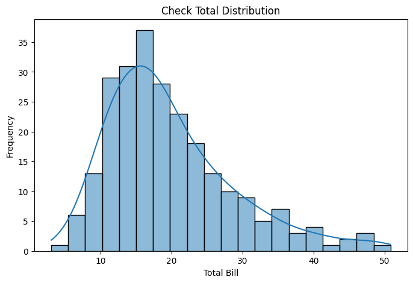

```python
# Histogram of check totals
plt.figure(figsize=(8, 5)) #inches
sns.histplot(data_tips['total_bill'], bins=20, kde=True)
plt.title("Check Total Distribution")
plt.xlabel("Total Bill")
plt.ylabel("Frequency")
plt.show()
```

We can analyze the relationship between total bill and tips

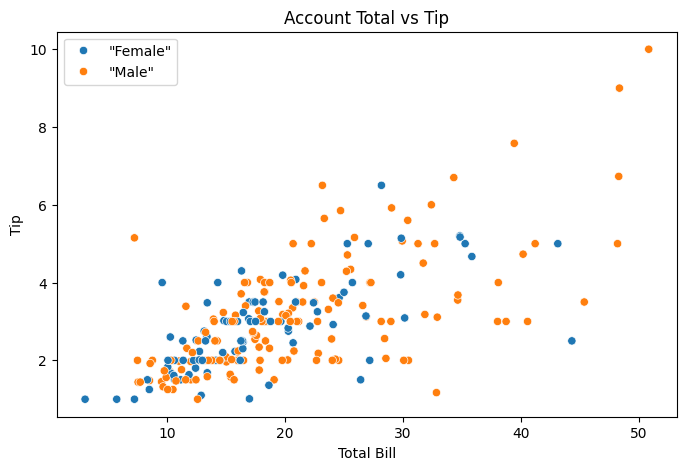

```python
plt.figure(figsize=(8, 5))
sns.scatterplot(x=data_tips['total_bill'], y=data_tips['tip'],\
                hue=data_tips['sex'])
plt.title("Account Total vs Tip")
plt.xlabel("Total Bill")
plt.ylabel("Tip")
plt.show()
```

To save the graph we need to add the instruction $\mathtt{savefig}$ before displaying the figure

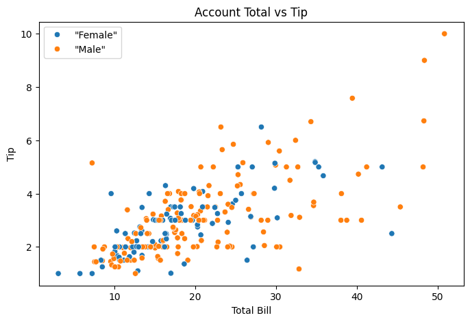

```python
plt.figure(figsize=(8, 5))
sns.scatterplot(x=data_tips['total_bill'], y=data_tips['tip'],\
                hue=data_tips['sex'])
plt.title("Account Total vs Tip")
plt.xlabel("Total Bill")
plt.ylabel("Tip")
plt.savefig("tip_graph.png")
plt.show()
```

Finally, to download the image automatically we use again the $\mathtt{download}$ function of the $\mathtt{files}$ method

```python
files.download("tip_graph.png")
```

### **Recap of section 2**

Business-related example: Import, explore, and export a dataset in the context of business administration, focuses on applying basic Python data handling techniques to a real-world business scenario using a restaurant tip dataset.

1. **Dataset Introduction:** The section introduces the `tips` dataset, describing its columns: `total_bill`, `tip`, `sex`, `smoker`, `day`, `time`, and `size`.
2. **Exploring Data with Pandas:**
   - **Importing Data:** Demonstrates how to read a CSV file from a URL using `pd.read_csv()`.
   - **Data Inspection:** Shows how to view the first few rows (`.head()`), get summary information about columns and data types (`.info()`), and calculate descriptive statistics (`.describe()`).
   - **Exporting Data:** Explains how to save a DataFrame to a CSV file (`.to_csv()`) and an Excel file (`.to_excel()`). It also includes how to download these files from Google Colab using `files.download()`.
   - **Uploading Data:** Shows how to upload files from your local computer to Google Colab using `files.upload()` and then read them into a Pandas DataFrame using `pd.read_excel()`, `pd.read_csv()`, and `pd.read_table()` (highlighting the need to specify the delimiter with `read_table`). It also mentions the option to read data without a header using the `header=None` argument in `read_csv`.
3. **Exploring Data with NumPy (Advanced):**
   - **Importing Data:** Shows how to load data from a URL into a NumPy structured array using `np.genfromtxt()`, specifying delimiters, skipping headers, data types, and column names.
   - **Data Inspection:** Demonstrates how to print the first few rows of a NumPy array and iterate through its data types.
   - **Descriptive Statistics:** Explains how to select numeric columns, create a 2D NumPy array from them, and calculate descriptive statistics like non-zero counts (`np.count_nonzero()`), mean (`np.mean()`), standard deviation (`np.std()`), minimum (`np.min()`), maximum (`np.max()`), median (`np.median()`), and percentiles (`np.percentile()`), often specifying the axis (`axis=0` for columns, `axis=1` for rows).
   - **Exporting Data:** Shows how to save NumPy arrays to text files (which can be used for CSV) using `np.savetxt()` and how to download them.
   - **Uploading Data:** Demonstrates how to upload files and load them into a NumPy array using `np.genfromtxt()`.
4. **Exploring Data with Matplotlib:**
   - **Importing Libraries:** Mentions importing `matplotlib.pyplot` and `seaborn` for visualization.
   - **Creating Visualizations:** Provides examples of creating visualizations:
     - A histogram of `total_bill` using `seaborn.histplot()`.
     - A scatter plot showing the relationship between `total_bill` and `tip`, colored by `sex`, using `seaborn.scatterplot()`.
   - **Customizing Plots:** Shows how to set figure size, add titles (`plt.title()`), and label axes (`plt.xlabel()`, `plt.ylabel()`).
   - **Displaying Plots:** Uses `plt.show()` to display the generated plots.
   - **Saving Plots:** Explains how to save plots to files (e.g., PNG) using `plt.savefig()` before calling `plt.show()`.
   - **Downloading Plots:** Shows how to automatically download the saved image files using `files.download()`.

In essence, Module 2 provides a practical application of basic data handling in Python using the Pandas, NumPy, and Matplotlib libraries within the Google Colab environment, simulating a typical workflow of importing, exploring, and exporting a dataset relevant to a business context.

## **3: Upload and open a file from Google Drive**

- The first step is to set up Drive in Google Collab

```python
from google.colab import drive
drive.mount('/content/drive')
```

- Next we determine our working directory

'/content/drive/MyDrive/'

- En esta carpeta se ubican las subcarpetas personales.
- For example, in my personal Google Drive cloud, I've created these folders and subfolders:

/Business_Statistics_2025Q3/Workshop/Notebooks/Introduction_Python_Data_Analytics_Tools/'

- Each user must locate or create a personal work folder to save their workbook and then assign it to a Python variable similar to the following:

```python
personal_folder='/content/drive/MyDrive/Business_Statistics_2025Q3/Workshop/Notebooks/'
```

- Once this is done, you must change your working directory to the personal folder defined above (it will be different for each one) as follows:

```python
import os
os.chdir(personal_folder)
```

- You can even verify that you are in your home folder with the following command (optional):

```python
os.getcwd()
```

```
'/content/drive/MyDrive/Business_Statistics_2025Q3/Workshop/Notebooks'
```

- If you get an error, you should carefully check that you have entered the folder names exactly as they appear in your Drive.
- Python (and any programming language) is very sensitive to spaces, capital letters, accents, and other characters.
- If all goes well, you can now continue loading the data.

### Example

```python
import pandas as pd
datos_gasolina = pd.read_csv('GASREGW.csv')
print(datos_gasolina)
```

```
     observation_date  GASREGW
0          1990-08-20    1.191
1          1990-08-27    1.245
2          1990-09-03    1.242
3          1990-09-10    1.252
4          1990-09-17    1.266
...               ...      ...
1816       2025-06-09    3.108
1817       2025-06-16    3.139
1818       2025-06-23    3.213
1819       2025-06-30    3.164
1820       2025-07-07    3.125

[1821 rows x 2 columns]
```

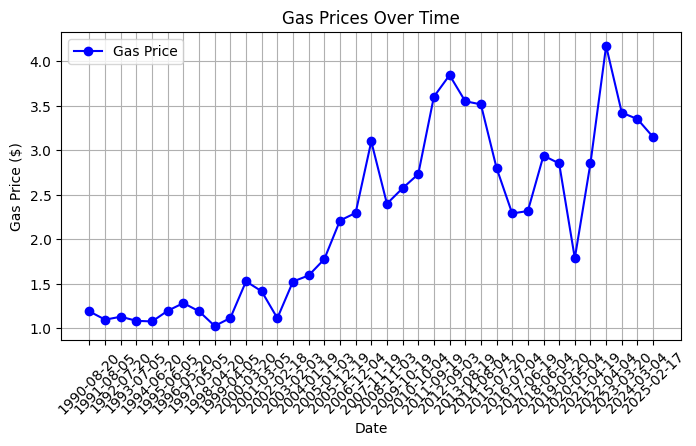

```python
import matplotlib.pyplot as plt

# Plot
plt.figure(figsize=(8, 4))
plt.plot(datos_gasolina["observation_date"][::50], \
         datos_gasolina["GASREGW"][::50], marker='o',\
         linestyle='-', color='b', label="Gas Price")

# Formatting
plt.xlabel("Date")
plt.ylabel("Gas Price ($)")
plt.title("Gas Prices Over Time")
plt.legend()
plt.grid(True)

# Rotate x-axis labels for readability
plt.xticks(rotation=45)

# Show plot
plt.savefig('gasoline.png', dpi=300)
plt.show()
```

The figure was saved in the Google Drive working folder, which we can corroborate with the following instruction (command):

```python
ls
```

```
'Análisis Descriptivo y Visualización de Datos.ipynb'
 gasoline.png
 GASREGW.csv
 Introducción_al_Análisis_Predictivo.ipynb
'Introduction to Python and Data Analytics Tools.ipynb'
'Manipulación de Datos con Pandas.ipynb'
```

### **Recap of section 3**

1. **Mounting Google Drive:** The essential first step is to connect Colab to your Google Drive account using `drive.mount('/content/drive')`.
2. **Identifying Working Directory:** It explains that `/content/drive/MyDrive/` is the base directory for your personal Drive content in Colab. Users need to locate or create a specific folder within their Drive where they store their data files and notebooks.
3. **Changing Working Directory:** It demonstrates how to change the current working directory in Colab to the specified personal folder in Google Drive using `os.chdir()`. This makes it easier to access files without typing the full path every time. An optional step `os.getcwd()` is provided to verify the current directory. It highlights the importance of exact spelling and case sensitivity when specifying folder names.
4. **Example:** A practical example is provided where a CSV file (`GASREGW.csv`) containing historical gasoline price data, assumed to be stored in the user's specified Drive folder, is loaded into a Pandas DataFrame using `pd.read_csv()`.
5. **Plotting Data from Drive:** The example then proceeds to create a line plot of the gasoline prices over time using `matplotlib.pyplot`, demonstrating that data loaded from Drive can be used for analysis and visualization.
6. **Saving Plots to Drive:** It shows how to save the generated plot image directly back to the working folder in Google Drive using `plt.savefig()`.
7. **Verifying Files in Drive:** Finally, the shell command `!ls` is used to list the contents of the current directory, confirming that the saved image file is now present in the specified Google Drive folder.

In summary, Section 3 provides a step-by-step guide on how to integrate Google Drive with Google Colab, enabling users to easily access, process, and save files directly within their cloud storage environment.

## **General Summary**

- Section 1 covers fundamental Python concepts and essential tools for data analytics. It introduces Python installation using Jupyter/Google Colab, basic syntax (variables, data types, operations, printing), fundamental data structures like lists (including operations like append, insert, remove, pop, slicing, and sorting), tuples, sets, and dictionaries. It also covers control flow with conditional statements (`if`, `elif`, `else`) and loops (`for`, `while`).
- Section 2 focuses on a practical business example using a restaurant tip dataset. It demonstrates how to import, explore, and export data using the Pandas library, including reading CSV/Excel files, inspecting data with `.head()`, `.info()`, and `.describe()`, and saving data using `.to_csv()`, `.to_excel()`, and `.savetxt()`. It also introduces basic data exploration and manipulation with NumPy (though noted as more advanced) and data visualization using Matplotlib and Seaborn, including creating histograms and scatter plots and saving figures.
- Section 3 guides users on how to integrate Google Drive with Google Colab. It explains how to mount Drive, identify and change the working directory within Drive, and then demonstrates loading data files directly from a specified Drive folder into a Pandas DataFrame. It concludes by showing how to create a plot using this data and save the resulting image file back to the Google Drive folder.

### **Referencias**

- Anderson, D. R., Williams, T. A. y Cochran, J. J. (2024). Estadística para la economía y los negocios. Cengage Learning.
- McKinney, W. (2012). Python para el análisis de datos: Manejo de datos con Pandas, NumPy e IPython. "O'Reilly Media, Inc."
- Bryant, P. G. y Smith, M. (1995) *Análisis práctico de datos: Casos prácticos en estadística empresarial*. Homewood, IL: Richard D. Irwin Publishing.
- OpenAI. (2025). *ChatGPT (versión GPT-4)*. Recuperado de https://chat.openai.com/